# IS 564 - Advanced Topics in Data Science (Assignment)

# Done by Salma Alfohaid

### This Notebook contains Program of Deep learning for *NLP Assignment*

  > **20 Newsgroups Dataset** has a collection of 20,000 news articles from 20 multiple newsgroups

#### First Step: imports all the libraries.

> The dataset I will be loading from sklearn.datasets which has train and test sets

```python
import pandas as pd # For dataframes
import numpy as np # For mathimatical functions
from sklearn.datasets import fetch_20newsgroups # Import the dataset for "sklearn"
import matplotlib.pyplot as plt
```

```python
from sklearn.model_selection import train_test_split
from sklearn.preprocessing import LabelEncoder
from tensorflow.keras.preprocessing.text import Tokenizer
from tensorflow.keras.preprocessing.sequence import pad_sequences
import tensorflow as tf
```

```python
# Load the 20 newsgroups dataset
newsgroups_data = fetch_20newsgroups(subset='all', remove=('headers', 'footers', 'quotes'))
```

#### Second Step: Preprocessing.

> In the preprocess part the dataset will be split into 2 sets training and testing

> tokenization will be applied to the data.

> Making all text sequences in a dataset have the same length by adding padding tokens.

> Encode the data labels as numbers to be ready in the model.

```python
# Split the dataset into training and testing sets
X_train, X_test, y_train, y_test = train_test_split(newsgroups_data.data, newsgroups_data.target, test_size=0.2, random_state=42)
```

```python
# Tokenize the text data
max_words = 10000
tokenizer = Tokenizer(num_words=max_words, oov_token='<OOV>')
tokenizer.fit_on_texts(X_train)
X_train_seq = tokenizer.texts_to_sequences(X_train)
X_test_seq = tokenizer.texts_to_sequences(X_test)
```

```python
# Pad the sequences
max_sequence_length = 250
X_train_padded = pad_sequences(X_train_seq, maxlen=max_sequence_length, padding='post', truncating='post')
X_test_padded = pad_sequences(X_test_seq, maxlen=max_sequence_length, padding='post', truncating='post')
```

```python
# Encode the labels
num_classes = len(np.unique(newsgroups_data.target))
label_encoder = LabelEncoder()
y_train_encoded = label_encoder.fit_transform(y_train)
y_test_encoded = label_encoder.transform(y_test)
```

#### Third Step: Build the model.

> using LSTM approche, **LSTM** is *Long Short-Term Memory* is a type of Neural Network specifically Recurrent Neural Network (RNN) that can learn patterns from sequences that can address the vanishing gradient problem in traditional RNNs.

```python
embedding_dim = 128
lstm_units = 64

model = tf.keras.Sequential([
    tf.keras.layers.Embedding(input_dim=max_words, output_dim=embedding_dim, input_length=max_sequence_length),
    tf.keras.layers.Bidirectional(tf.keras.layers.LSTM(lstm_units, return_sequences=True)),
    tf.keras.layers.GlobalMaxPool1D(),
    tf.keras.layers.Dense(64, activation='relu'),
    tf.keras.layers.Dropout(0.5),
    tf.keras.layers.Dense(num_classes, activation='softmax')
])

model.compile(loss='sparse_categorical_crossentropy', optimizer='adam', metrics=['accuracy'])
model.summary()
```

```
Model: "sequential"
_________________________________________________________________
 Layer (type)                Output Shape              Param #
=================================================================
 embedding (Embedding)       (None, 250, 128)          1280000

 bidirectional (Bidirectiona  (None, 250, 128)         98816
 l)

 global_max_pooling1d (Globa  (None, 128)              0
 lMaxPooling1D)

 dense (Dense)               (None, 64)                8256

 dropout (Dropout)           (None, 64)                0

 dense_1 (Dense)             (None, 20)                1300

=================================================================
Total params: 1,388,372
Trainable params: 1,388,372
Non-trainable params: 0
_________________________________________________________________
```

#### Fourth Step: Train the model.

> Train the data using fit method.

```python
epochs = 10
batch_size = 128

history = model.fit(X_train_padded, y_train_encoded, epochs=epochs, batch_size=batch_size, validation_split=0.1, verbose=1)
```

#### Fifth Step: Evaluate.

> Evaluate the test data by findinh **loss** and **accuracy**

```python
loss, accuracy = model.evaluate(X_test_padded, y_test_encoded, verbose=1)
print(f"Loss: {loss:.4f}, Accuracy: {accuracy:.4f}")
```

```
Loss: 1.5959, Accuracy: 0.6164
```

### Let's Check

#### Sample of the Original Text Data:

```python
print("Original Text Data:")
for i in range(3):
    print(f"Sample {i + 1}: {X_train[i]}")
    print()

print("Labels:")
for i in range(3):
    print(f"Sample {i + 1}: {y_train[i]} - {newsgroups_data.target_names[y_train[i]]}")
    print()
```

```
Original Text Data:
Sample 1: #
# I've gotten very few posts on this group in the last couple days.  (I
# recently added it to my feed list.)  Is it just me, or is this group
# near death?
#

Seen from the mailing list side, I'm getting about the right amount of
traffic.

Patrick L. Mahan

--- TGV Window Washer ------------------------------- Mahan@TGV.COM ---------

Waking a person unnecessarily should not be considered  - Lazarus Long
a capital crime.  For a first offense, that is            From the Notebooks of
							  Lazarus Long

Patrick L. Mahan

--- TGV Window Washer ------------------------------- Mahan@TGV.COM ---------

Sample 2: Interesting.  I'd fight the ticket.  First off, there's a 50/50 chance
the cop won't show up.  Secondly, if he does show up, you should point
out that he lied (purgered) on the ticket.  Why 70+?  I beleive that if
yo're charged with going more than 15mph that the posted speed it's a
more severe ticket.  You couldn't have p[ossibly been going 70+, right?!


Sample 3: I remember as a kid visiting my relatives on Kauai, and one of the things
that really frightened me was centipedes.  I'd been told they were poisonous
and infrequently one would pop up and scare the heck out of me.  Once
one came out of the vacuum cleaner and it seemed like it was at least a foot
long and moving at 35 miles an hour!


Labels:
Sample 1: 5 - comp.windows.x

Sample 2: 8 - rec.motorcycles

Sample 3: 13 - sci.med
```

#### Sample of the Original Text Data:

```python
print("Original Test Text Data:")
for i in range(3):
    print(f"Sample {i + 1}: {X_test[i]}")
    print()

print("Test Labels:")
for i in range(3):
    print(f"Sample {i + 1}: {y_test[i]} - {newsgroups_data.target_names[y_test[i]]}")
    print()
```

```
Original Test Text Data:
Sample 1:


	The runner can leave his base at any time.  If the ball is caught,
he's got to tag up.  If it isn't caught, he _doesn't_ have to tag up at
all.  So, if he's feeling lucky, your runner at second can sprint for glory
as soon as the ball is popped up.  If it isn't caught, he's probably scored
a run.  If it is, he's probably headed for AAA.

	The only effect the infield fly has is to make the batter out,
thereby removing the force on the runners on base.  All other rules apply,
as if you were standing second with first open and the ball is popped up.


Sample 2:
Well, it's not an FTP site, but I got an 800 number for Signetics BBS.

The Signetics BBS contain some pretty good items for the 8051.  I am
currently using the following files which I downloaded from them:

    ml-asm51.zip      MetaLink's 8051 family macro assembler
    bootstrp.zip      Hex file Load-and-Go using 8051 uart
                      (allows you to download your program into a RAM
                       and then execute from RAM.  Works great.  Tell
                       me if you want more details).
    tutor51.zip       TSR for 8051 feature help screens

They have lots of coding examples, assemblers, and misc. tools.

Signetics BBS numbers are:    (800) 451-6644
                              (408) 991-2406

Have fun,
--
Mont Pierce

Sample 3: Hi,
    I was reading through "The Spaceflight Handbook" and somewhere in
there the author discusses solar sails and the forces acting on them
when and if they try to gain an initial acceleration by passing close to
the sun in a hyperbolic orbit. The magnitude of such accelerations he
estimated to be on the order of 700g. He also says that this is may not
be a big problem for manned craft because humans (and this was published
in 1986) have already withstood accelerations of 45g. All this is very
long-winded but here's my question finally - Are 45g accelerations in
fact humanly tolerable? - with the aid of any mechanical devices of
course. If these are possible, what is used to absorb the acceleration?
Can this be extended to larger accelerations?

Test Labels:
Sample 1: 9 - rec.sport.baseball

Sample 2: 12 - sci.electronics

Sample 3: 14 - sci.space
```

#### Sample of the tokenized and padded text data:

```python
print("Tokenized and Padded Text Data:")
for i in range(3):
    print(f"Sample {i + 1}: {X_train_padded[i]}")
    print()

print("Encoded Labels:")
for i in range(3):
    print(f"Sample {i + 1}: {y_train_encoded[i]}")
    print()
```

```
Tokenized and Padded Text Data:
Sample 1: [ 180 1965  107  229 1543   15   16  299    8    2  184  593  459    7
  771 1274   12    3   39 3180  253    9   12   70   56   23    9   16
  299  769  644  337   29    2 1395  253  518  101  387   46    2  133
 1096    4 1656 3445  174    1 9184  349 9471    1 9184  188    1    5
  369    1  100   21   17  841    1  232    5 3550  948   13    5  115
 3314   10    9   29    2    1    4    1  232 3445  174    1 9184  349
 9471    1 9184  188    0    0    0    0    0    0    0    0    0    0
    0    0    0    0    0    0    0    0    0    0    0    0    0    0
    0    0    0    0    0    0    0    0    0    0    0    0    0    0
    0    0    0    0    0    0    0    0    0    0    0    0    0    0
    0    0    0    0    0    0    0    0    0    0    0    0    0    0
    0    0    0    0    0    0    0    0    0    0    0    0    0    0
    0    0    0    0    0    0    0    0    0    0    0    0    0    0
    0    0    0    0    0    0    0    0    0    0    0    0    0    0
```

[output cut: 49 more lines]

#### Sample of the tokenized and padded test text data:

```python
print("Tokenized and Padded Test Text Data:")
for i in range(3):
    print(f"Sample {i + 1}: {X_test_padded[i]}")
    print()

print("Encoded Test Labels:")
for i in range(3):
    print(f"Sample {i + 1}: {y_test_encoded[i]}")
    print()
```

```
Tokenized and Padded Test Text Data:
Sample 1: [   2 5845   35  843   79  981   32   55   85   26    2 1984    9 2359
  621  213    3 6752   72   26   12  351 2359   47  230   18    3 6752
   72   32   37   49   26  621 1982 3130   51 5845   32  279   35    1
   13 4513   22  784   22    2 1984    9    1   72   26   12  351 2359
  621  247 2556    5  260   26   12    9  621  247 4514   13 6630    2
   78  693    2 9472 2432   50    9    3  125    2 6081   59 7205 3968
    2  586   15    2 6350   15  981   37   71  911 1348   22   26   14
   63 2604  279   19  115  410    6    2 1984    9    1   72    0    0
    0    0    0    0    0    0    0    0    0    0    0    0    0    0
    0    0    0    0    0    0    0    0    0    0    0    0    0    0
    0    0    0    0    0    0    0    0    0    0    0    0    0    0
    0    0    0    0    0    0    0    0    0    0    0    0    0    0
    0    0    0    0    0    0    0    0    0    0    0    0    0    0
    0    0    0    0    0    0    0    0    0    0    0    0    0    0
```

[output cut: 49 more lines]

#### Lets visualize to get more insights

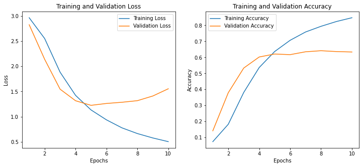

```python
# Get the training history data
history_dict = history.history
train_loss = history_dict['loss']
val_loss = history_dict['val_loss']
train_acc = history_dict['accuracy']
val_acc = history_dict['val_accuracy']

# Set up the plots
epochs_range = range(1, len(train_loss) + 1)

plt.figure(figsize=(12, 5))

# training and validation loss
plt.subplot(1, 2, 1)
plt.plot(epochs_range, train_loss, label='Training Loss')
plt.plot(epochs_range, val_loss, label='Validation Loss')
plt.xlabel('Epochs')
plt.ylabel('Loss')
plt.legend()
plt.title('Training and Validation Loss')

# training and validation accuracy
plt.subplot(1, 2, 2)
plt.plot(epochs_range, train_acc, label='Training Accuracy')
plt.plot(epochs_range, val_acc, label='Validation Accuracy')
plt.xlabel('Epochs')
plt.ylabel('Accuracy')
plt.legend()
plt.title('Training and Validation Accuracy')

# Show the plots
plt.show()
```

> As we can see the model learning process of the loss and accuracy of the training and validation, the accuracy is higher in training set but we got 20% less on the testing, also the loss is less in training.

### Refrences:

- https://machinelearningmastery.com/
- http://qwone.com/~jason/20Newsgroups/
- https://scikit-learn.org/0.19/datasets/twenty_newsgroups.html